# Fraud Analysis using K-Means Algorithm

Yaumil Sitta

April 7, 2020

# Unsupervised Learning

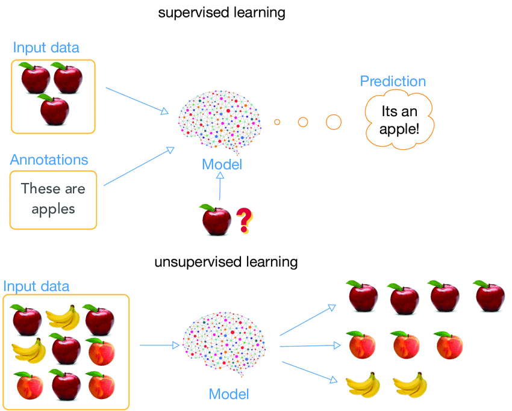

Source: [Research Gate](https://www.researchgate.net/figure/Supervised-learning-and-unsupervised-learning-Supervised-learning-uses-annotation_fig1_329533120)

# Clustering Analysis

[Cluster analysis](https://en.wikipedia.org/wiki/Cluster_analysis) or clustering is the task of grouping a set of objects in such a way that objects in the same group (called a cluster) are more similar (in some sense) to each other than to those in other groups (clusters). In this article, we will discuss about one of the common clustering algorithms, that is kmeans.

# Kmeans Clustering Analysis

K-means is a centroid-based clustering algorithm that follows a simple procedure of classifying a given dataset into a pre-determined number of clusters, denoted as “k”. We will discuss about one use case that can be done using kmeans algorithm.

The use case that will be discuss here is fraud analysis in mobile financial industry.

```r
library(tidyverse)
library(factoextra)
```

```r
paysim <- read_csv("paysim1.csv")
```

PaySim simulates mobile money transactions based on a sample of real transactions extracted from one month of financial logs from a mobile money service implemented in an African country. The original logs were provided by a multinational company, who is the provider of the mobile financial service which is currently running in more than 14 countries all around the world. The dataset is downloaded from [kaggle](https://www.kaggle.com/ntnu-testimon/paysim1).

```r
fr <- paysim %>%
  filter(Fraud == "Yes" & amount == 0)
summary(fr)
```

```
##       step           type               amount    nameOrig
##  Min.   :387.0   Length:2           Min.   :0   Length:2
##  1st Qu.:472.8   Class :character   1st Qu.:0   Class :character
##  Median :558.5   Mode  :character   Median :0   Mode  :character
##  Mean   :558.5                      Mean   :0
##  3rd Qu.:644.2                      3rd Qu.:0
##  Max.   :730.0                      Max.   :0
##  oldbalanceOrg newbalanceOrig   nameDest         oldbalanceDest
##  Min.   :0     Min.   :0      Length:2           Min.   :1008610
##  1st Qu.:0     1st Qu.:0      Class :character   1st Qu.:2749149
##  Median :0     Median :0      Mode  :character   Median :4489688
##  Mean   :0     Mean   :0                         Mean   :4489688
##  3rd Qu.:0     3rd Qu.:0                         3rd Qu.:6230228
##  Max.   :0     Max.   :0                         Max.   :7970767
##  newbalanceDest       Fraud           FlaggedFraud
##  Min.   :1008610   Length:2           Length:2
##  1st Qu.:2749149   Class :character   Class :character
##  Median :4489688   Mode  :character   Mode  :character
##  Mean   :4489688
##  3rd Qu.:6230228
##  Max.   :7970767
```

```r
summary(paysim)
```

[output not shown]

```r
table(paysim$Fraud == "Yes")
```

```
##
##  FALSE   TRUE
## 118028    833
```

```r
head(paysim)
```

| type | amount | nameOrig | oldbalanceOrg | newbalanceOrig | nameDest | oldbalanceDest | newbalanceDest | Fraud | FlaggedFraud |
| --- | --- | --- | --- | --- | --- | --- | --- | --- | --- |
| CASH_OUT | 129136.6 | C1385815368 | 132.0 | 0 | C544048607 | 113056.48 | 242193.1 | No | No |
| CASH_OUT | 146824.1 | C1906311191 | 34818.0 | 0 | C2054143317 | 54610.20 | 201434.3 | No | No |
| CASH_OUT | 211157.9 | C94356064 | 194437.6 | 0 | C920320711 | 894483.29 | 1105641.2 | No | No |
| CASH_OUT | 101700.6 | C579148643 | 18497.0 | 0 | C2103903159 | 62113.79 | 163814.3 | No | No |
| TRANSFER | 468784.0 | C2104331843 | 213690.0 | 0 | C462441263 | 1158836.31 | 1627620.3 | No | No |
| CASH_OUT | 322601.5 | C788769300 | 5258.0 | 0 | C350613541 | 2849048.39 | 3171649.8 | No | No |

Variables Description:

- `step` = maps a unit of time in the real world. In this case 1 step is 1 hour of time. Total steps 744 (30 days simulation).
- `type` = CASH-IN, CASH-OUT, DEBIT, PAYMENT and TRANSFER.
- `amount` = amount of the transaction in local currency.
- `nameOrig` = customer who started the transaction
- `oldbalanceOrg` = initial balance before the transaction
- `newbalanceOrig` = new balance after the transaction
- `nameDest` = customer who is the recipient of the transaction
- `oldbalanceDest` = initial balance recipient before the transaction. Note that there is not information for customers that start with M (Merchants).
- `newbalanceDest` = new balance recipient after the transaction. Note that there is not information for customers that start with M (Merchants).
- `Fraud` = This is the transactions made by the fraudulent agents inside the simulation. In this specific dataset the fraudulent behavior of the agents aims to profit by taking control or customers accounts and try to empty the funds by transferring to another account and then cashing out of the system.
- `FlaggedFraud` = The business model aims to control massive transfers from one account to another and flags illegal attempts. An illegal attempt in this dataset is an attempt to transfer more than 200.000 in a single transaction.

```r
paysim_num <- paysim %>%
  select_if(is.numeric) %>%
  scale()

paysim_num <- as.data.frame(paysim_num) %>%
  select(-c(newbalanceOrig, oldbalanceDest))
```

```r
wss <- function(data, maxCluster = 9) {
    # Initialize within sum of squares
    SSw <- (nrow(data) - 1) * sum(apply(data, 2, var))
    SSw <- vector()
    for (i in 2:maxCluster) {
        SSw[i] <- sum(kmeans(data, centers = i)$withinss)
    }
    plot(1:maxCluster, SSw, type = "o", xlab = "Number of Clusters", ylab = "Within groups sum of squares", pch=19)
}
```

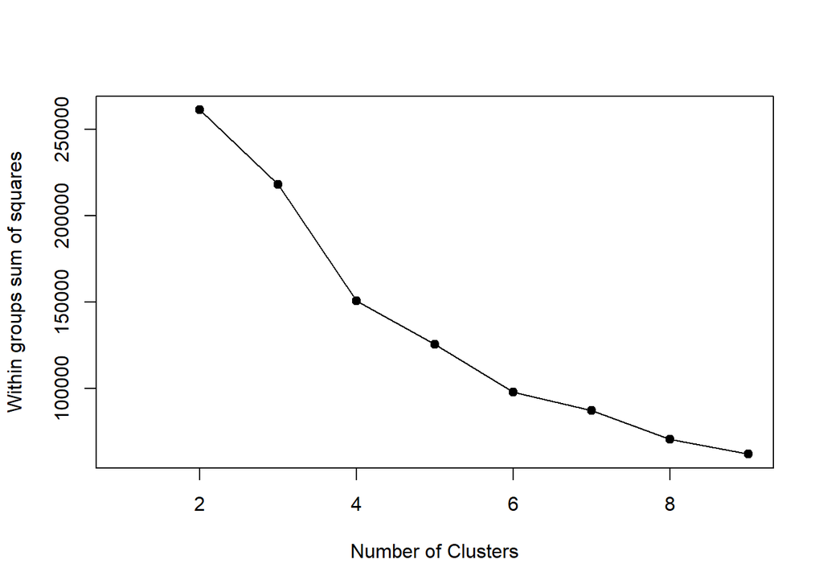

```r
options(scipen = 999)
wss(paysim_num)
```

```r
RNGkind(sample.kind = "Rounding")
set.seed(100)
pay_km <- kmeans(paysim_num, centers = 6)
```

```r
paysim$cluster <- pay_km$cluster
```

```r
paysim_num
```

| amount | oldbalanceOrg | newbalanceDest |
| --- | --- | --- |
| -0.31437668274 | -0.235748748185 | -0.34698681263 |
| -0.28940406777 | -0.075226992312 | -0.35805320796 |
| -0.19857236271 | 0.663469406218 | -0.11255257413 |
| -0.35311308916 | -0.150758203106 | -0.36826736802 |
| 0.16516500426 | 0.752566570408 | 0.02916964057 |
| -0.04122733020 | -0.212026366803 | 0.44838809314 |
| -0.33723710979 | 0.177231718015 | 1.12554281010 |
| 0.26174087612 | -0.231296752303 | -0.15310104310 |
| -0.38552877309 | -0.187841199987 | -0.29454102384 |
| 0.40277927736 | 0.104981655952 | 0.09132542643 |

[output cut: 9990 more lines]

```r
paysim %>%
  select(-c(type,nameOrig, nameDest, Fraud, FlaggedFraud)) %>%
  group_by(cluster) %>%
  summarise_all("mean")
```

| cluster | amount | oldbalanceOrg | newbalanceOrig | oldbalanceDest | newbalanceDest |
| --- | --- | --- | --- | --- | --- |
| 1 | 1324908.9 | 66278.97 | 0 | 94298673.4 | 98022259.3 |
| 2 | 1955059.2 | 186078.58 | 0 | 1278601.9 | 3224738.1 |
| 3 | 323390.7 | 50700.17 | 0 | 10207684.9 | 10657698.5 |
| 4 | 241041.5 | 39498.93 | 0 | 643174.4 | 894354.9 |
| 5 | 9267995.6 | 72138.57 | 0 | 3187950.1 | 17837947.2 |
| 6 | 6986284.5 | 6986284.54 | 0 | 455275.2 | 4934384.2 |

```r
paysim %>%
  select(-c(type,nameOrig, nameDest, FlaggedFraud)) %>%
  group_by(Fraud) %>%
  summarise_all("mean")
```

| Fraud | amount | oldbalanceOrg | newbalanceOrig | oldbalanceDest | newbalanceDest | cluster |
| --- | --- | --- | --- | --- | --- | --- |
| No | 344987.2 | 42136.25 | 0 | 1140542.9 | 1519986 | 3.875055 |
| Yes | 1317361.4 | 1317361.37 | 0 | 776860.3 | 1548377 | 3.543818 |

```r
table(paysim$Fraud, paysim$cluster)
```

```
##
##            1      2      3      4      5      6
##   No      53   4891   5173 107544    367      0
##   Yes      1    263      9    481      0     79
```

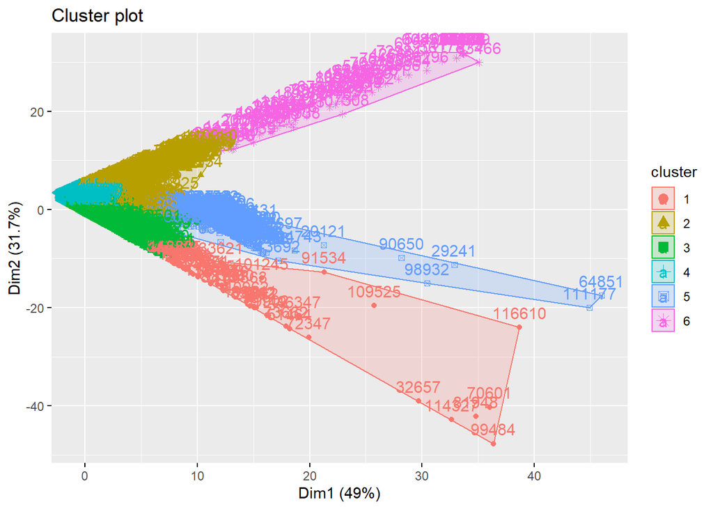

```r
fviz_cluster(pay_km, paysim_num)
```

```r
paysim %>%
  filter(newbalanceOrig == 0)
```

| type | amount | nameOrig | oldbalanceOrg | newbalanceOrig | nameDest | oldbalanceDest | newbalanceDest | Fraud | FlaggedFraud | cluster |
| --- | --- | --- | --- | --- | --- | --- | --- | --- | --- | --- |
| CASH_OUT | 129136.58 | C1385815368 | 132.00 | 0 | C544048607 | 113056.48 | 242193.06 | No | No | 4 |
| CASH_OUT | 146824.06 | C1906311191 | 34818.00 | 0 | C2054143317 | 54610.20 | 201434.26 | No | No | 4 |
| CASH_OUT | 211157.89 | C94356064 | 194437.63 | 0 | C920320711 | 894483.29 | 1105641.18 | No | No | 4 |
| CASH_OUT | 101700.55 | C579148643 | 18497.00 | 0 | C2103903159 | 62113.79 | 163814.34 | No | No | 4 |
| TRANSFER | 468783.99 | C2104331843 | 213690.00 | 0 | C462441263 | 1158836.31 | 1627620.31 | No | No | 4 |
| CASH_OUT | 322601.45 | C788769300 | 5258.00 | 0 | C350613541 | 2849048.39 | 3171649.83 | No | No | 4 |
| CASH_OUT | 112945.11 | C1713216847 | 89370.00 | 0 | C111311560 | 5552743.01 | 5665688.12 | No | No | 4 |
| TRANSFER | 537186.27 | C577841717 | 1094.00 | 0 | C438041839 | 419110.26 | 956296.53 | No | No | 4 |
| CASH_OUT | 78741.33 | C1151404621 | 10484.00 | 0 | C612134352 | 356615.57 | 435356.90 | No | No | 4 |
| TRANSFER | 637080.25 | C854220362 | 73758.00 | 0 | C1133140568 | 1219466.93 | 1856547.18 | No | No | 4 |

[output cut: 9990 more lines]

# Another cases of unsupervised learning

1. [Clustering AirBnB Review](https://arxiv.org/pdf/1705.03134.pdf)
2. [Why Tourists Choose Airbnb: A Motivation-Based Segmentation Study](https://www.researchgate.net/publication/316533754_Why_Tourists_Choose_Airbnb_A_Motivation-Based_Segmentation_Study)
3. [Clustering the weapon in PUBG game](https://algorit.ma/blog/data-science-analysis-pubg/?utm_source=Instagram&utm_medium=Social&utm_campaign=Blog)
4. [A Taxi Driving Fraud Detection System](https://ieeexplore.ieee.org/abstract/document/6137222?utm_source=datafloq&utm_medium=ref&utm_campaign=datafloq)